# SIP/DLA Data Visualization Workshop

#### ggokabeito

The package **ggokabeito** offers a custom palette which is colorblind-friendly. More information can be found [here](https://cran.r-project.org/web/packages/ggokabeito/ggokabeito.pdf).

To use this colorblind-friendly palette in your graphs, you can use the following line of code:

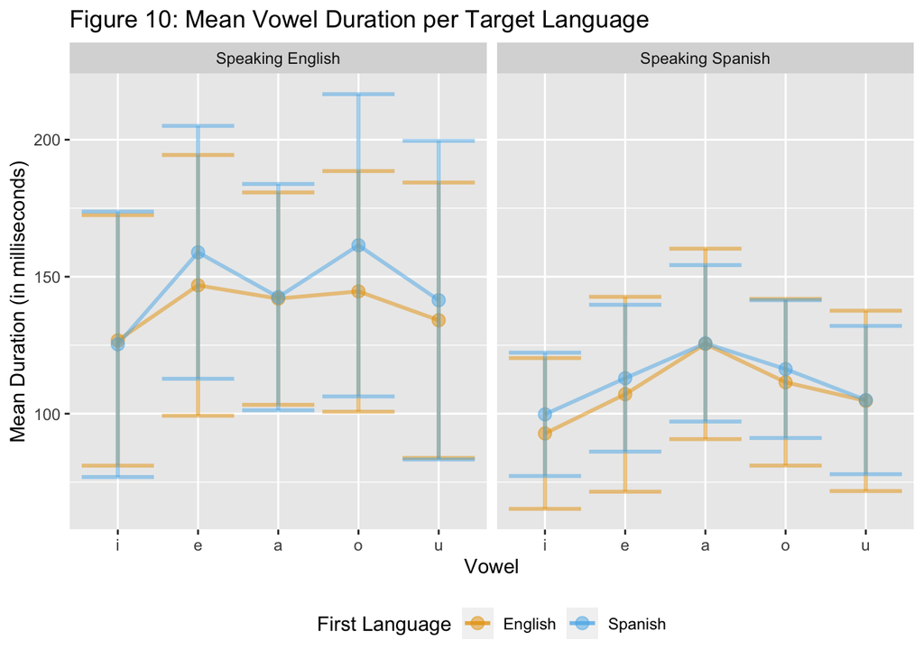

```r
library(ggokabeito)

# primary ggplot information +
# scale_color_okabe_ito()

# Here is an example:

vowels.raw %>%
  group_by(vowel, l1, target) %>%
  summarize(mean(vduration), sd(vduration)) %>%
  ggplot(aes(x=factor(vowel, levels=c("i", "e", "a", "o", "u")), y=`mean(vduration)`, color=l1)) +
  geom_line(aes(group=l1), alpha = 0.5, linewidth=1)+
  geom_point(alpha=0.5, size=3)+
  geom_errorbar(aes(ymin=`mean(vduration)`-`sd(vduration)`, ymax=`mean(vduration)`+`sd(vduration)`), alpha=0.5, linewidth=1)+
  facet_grid(.~target, labeller=as_labeller(c(eng="Speaking English", snh="Speaking Spanish")))+
  xlab("Vowel")+
  ylab("Mean Duration (in milliseconds)")+
  scale_y_continuous(labels=function(x)x*1000)+
  labs(title="Figure 10: Mean Vowel Duration per Target Language")+
# Modified scale_color_discrete to scale_color_okabe_ito. These commands take the same arguments.
  scale_color_okabe_ito(name="First Language", labels=c("English", "Spanish"))+
  theme(legend.position="bottom")
```

### VII. Saving Your Work! (!!!!!)

When you land on a plot with which you are satisfied, you should export it to your files. R Studio offers a very convenient point-and-click method for saving plots, under the Plots tab in the files/plots/packages pane: the Export function which lets you save your plot as an image file or PDF. You can also use different command options for saving your work. Here are two options for saving your plots: the *ggsave* command, and saving by the particular file type you want. It is also useful to keep a list of figures and comments of descriptions of figures when you save them.

```r
# ggsave

# ggsave(
#  filename,
#  plot = last_plot(),
#  device = NULL, # can be png, eps, ps, tex, pdf, jpeg, tiff, png, etc.
#  path = NULL, # defaults to working directory!
#  scale = 1,
#  width = NA,
#  height = NA,
#  units = c("in", "cm", "mm", "px"),
#  dpi = 300,
#  limitsize = TRUE, # When TRUE, ggsave will not save images larger than 50x50 inches.
#  bg = NULL,
#  ...
# )

# saving specific file types: BMP, JPEG, TIFF and PNG file types

# bmp(filename = "Rplot%03d.bmp",
#   width = 480, height = 480, units = "px", pointsize = 12,
#   bg = "white", res = NA, …,
#   type = c("cairo", "Xlib", "quartz"), antialias)

# jpeg(filename = "Rplot%03d.jpeg",
#     width = 480, height = 480, units = "px", pointsize = 12,
#     quality = 75,
#     bg = "white", res = NA, …,
#     type = c("cairo", "Xlib", "quartz"), antialias)

# png(filename = "Rplot%03d.png",
#    width = 480, height = 480, units = "px", pointsize = 12,
#     bg = "white",  res = NA, …,
#    type = c("cairo", "cairo-png", "Xlib", "quartz"), antialias)

#tiff(filename = "Rplot%03d.tiff",
#     width = 480, height = 480, units = "px", pointsize = 12,
#     compression = c("none", "rle", "lzw", "jpeg", "zip", "lzw+p", "zip+p"),
#     bg = "white", res = NA,  …,
#     type = c("cairo", "Xlib", "quartz"), antialias)

# Example: Saving Figure 10
vowel.means <- vowels.raw %>%
  group_by(vowel, l1, target) %>%
  summarize(mean(vduration), sd(vduration))

fig10 <- ggplot(vowel.means, aes(x=factor(vowel, levels=c("i", "e", "a", "o", "u")), y=`mean(vduration)`, color=l1)) +
    geom_line(aes(group=l1), alpha = 0.5, linewidth=1)+
    geom_point(alpha=0.5, size=3)+
    geom_errorbar(aes(ymin=`mean(vduration)`-`sd(vduration)`, ymax=`mean(vduration)`+`sd(vduration)`), alpha=0.5, linewidth=1)+
    facet_grid(.~target, labeller=as_labeller(c(eng="Speaking English", snh="Speaking Spanish")))+
    xlab("Vowel")+
    ylab("Mean Duration (in milliseconds)")+
    scale_y_continuous(labels=function(x)x*1000)+
    labs(title="Figure 10: Mean Vowel Duration per Target Language")+
    scale_color_discrete(name="First Language", labels=c("English", "Spanish"))+
    theme(legend.position="bottom")

png(filename="./fig10.png", width=6.5, height=4.2, res=300, units="in")
# Figure 10: Mean vowel duration per target language
fig10
dev.off()
```

### VIII. Best Practices for Dataframe Formatting

Of course, no plot can be made successfully without a data frame which conforms to the format that best suits your needs. Here are some questions that you can ask yourself about your data frame that will help you prepare to visualize and analyze:

- What format is your data frame in? Long, or wide? Long format is typical, where columns represent individual factors/variables and rows represent unique observations.
- What are the class types of your data? Numeric, factor, character, integer?
- If you are working with character factors, are all of the levels uniform in terms of spelling, capitalization, spacing, etc.?
- Are any and all numeric variables formatted in the best way? For example, the vowels.raw dataframe includes duration in seconds, but often linguists discuss vowel length in milliseconds, so this factor had to be transformed while I was plotting.
- Do you have any missing values? Is this intentional, or something to be fixed with data manipulation? Should these rows/observations be removed altogether?

Considering these wrangling questions before visualization and analysis will prevent many, if not all, errors which may hinder the process of analysis. There are extra resources listed at the end of this document which can help in the wrangling and formatting process.

### IX. Extra Resources

For more advanced considerations for visualizing data, you can consult:

- Healy, K. (2018). Data visualization: a practical introduction. Princeton University Press.

In addition, there is a folder within this R Project called “Cheat Sheets” which contains PDFs or JPGs of various useful packages and capabilities in R for data frame manipulation, pipe commands, and more.

### X. Open-Ended Q&A / Bring Your Data

#### Plotting Proportions & Labelling:

```r
cp1 %>% # if you want a new df you can create one, not obligatory
  group_by(verbGroup) %>% # all factors you want to form your plot
  mutate(Freq_vG = n()) %>% # get frequency of tokens
  group_by(verbGroup, Freq_vG, vcp) %>% # all the groups you want means for, such as verb type.
  summarise(Freq_vcp = n(), Prop = Freq_vcp / Freq_vG) %>%
  distinct() %>% ##gets rid of all the duplicates
  ggplot(aes(x = verbGroup, y = Prop, fill = vcp)) +
  geom_col() +
  geom_text(aes(label=scales::percent(Prop)), position=position_stack(0.5))
```

[output not shown]